# R for Beginners

### Lines

The `reg` parameter of the `abline()` function accepts any regression object with a `coefficients` method and uses the coefficients to draw the line.

The `lines()` function joins a set of x and y coordinates using lines. This function is essentially identical to the `points()` function but its default value is `type = "l"`, instead of `type = "p"`. The `lty`, `lwd` and `col` parameters determine the line type, width and colour in both the `abline()` and `lines()` functions. Figure below shows six types of lines created by the `lty` parameter.

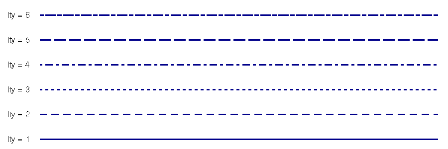

The following Code contains an example of the use of the `lines()` and `ablines()` functions.

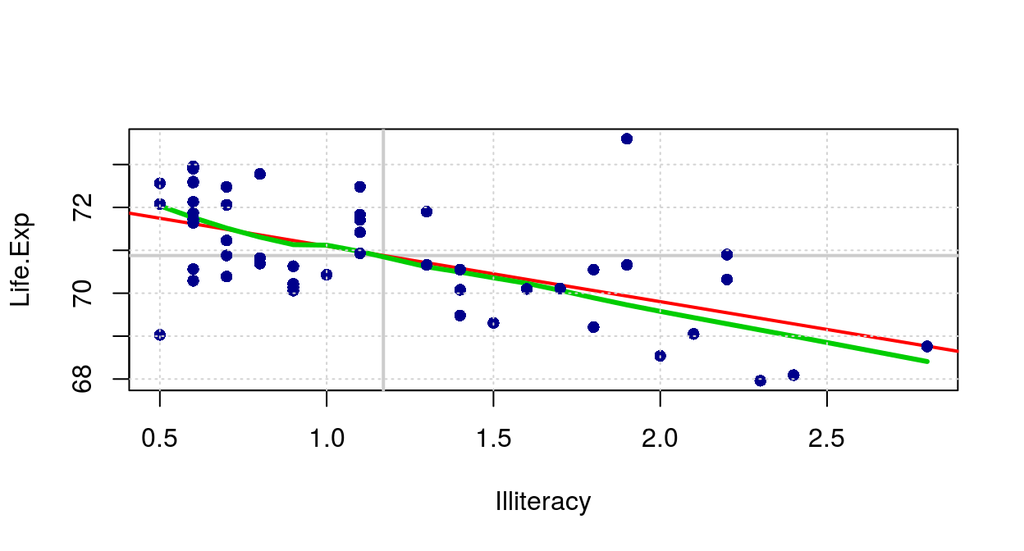

```r
plot(Life.Exp ~ Illiteracy, data = states, type = "n")
abline(h = mean(states$Life.Exp), v = mean(states$Illiteracy),
  col = "gray80", lwd = 2)
abline(lsfit(states$Illiteracy, states$Life.Exp), col = "red", lwd = 2)
lines(lowess(states$Illiteracy, states$Life.Exp), col = "green3", lwd = 3)
points(Life.Exp ~ Illiteracy, data = states, pch = 16, col = "darkblue")
grid()
```

In the example, the abline function is firstly used to express the `h` and `v` parameters. In the second use of the function the `lsfit` argument has been specified. The `lines()` function has drawn the local regression line. The `abline()` function does not accept an object produced by the `lowess()` function. This happens because a coefficients method does not exist for this model. By default, the `grid()` function draws a grid which aligns with the tick marks on the axes. A smaller or larger grid can be obtained specifying the `nx` and `ny` parameters which determine the number of vertical and horizontal lines respectively. The grid can be better controlled with the explicit use of `abline()`. The `points()` function has been used at the end of the code to prevent points from being hidden by a line drawn in the plot.

### Legend

The `inset` parameter, as a fraction of the plot region, defines the distance of the legend from the plot margins. A single value refers to the margin of the x-axis. Two values, on the other hand, are referred to the margins of the x and y axes. The `legend` parameter defines the legend text. The `ncol` parameter sets the number of columns of the legend; if it is not specified the legend will have only one column. The width and the line type of the legend box can be set using the `box.lwd` and `box.lty` parameters. The`bty = "n"` parameter eliminates the margins of the legend. The `title` parameter inserts a title for the legend. As it can be seen, there are no limits as to how many legends can be inserted in a plot.

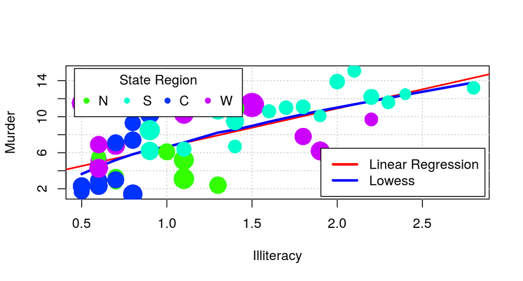

```r
myCol = as.character(factor(states$states.region.abb,
  labels = rainbow(4, start = 0.3, end = 0.8)))
myCex = 4*states$Income/max(states$Income)
plot(Murder ~ Illiteracy, data = states, type = "n")
grid(col = "gray80", lwd = 1, lty = 3)
abline(reg = lsfit(states$Illiteracy, states$Murder),
  col = "red", lwd = 2)
lines(lowess(states$Illiteracy, states$Murder),
  col = "blue", lwd = 3)
points(Murder ~ Illiteracy, data = states, pch = 16,
  cex = myCex, col = myCol)
legend(x = "topleft", legend = levels(states$states.region.abb),
  col = rainbow(4, start = 0.3, end = 0.8), pch = 16, ncol = 4,
  title = "State Region", inset = c(0.02, 0.02), bg = "white")
legend(x = "bottomright", legend = c("Linear Regression", "Lowess"),
  col = c("red", "blue"), ncol = 1, lty = 1, lwd = 3,
  inset = c(0.01, 0.02), bg = "white")
```

### Titles

`title()` is a low-level function which inserts the title in a plot. There are four different positions for a title in a graph:

1. top-centre
2. bottom-centre
3. as label for the x-axis
4. as label for the y-axis

If the `outer` parameter is set on `TRUE`, the title will be placed in the outer margin of the plot. The `cex` parameter controls the size of the title. The function is usually used to define main titles, whereas axes labels are managed with the `xlab` and `ylab` parameters of the `plot()` function or the `label` parameter of the `axis()` function. The “`\n`” symbol inside the string of the main title splits the title over two lines.

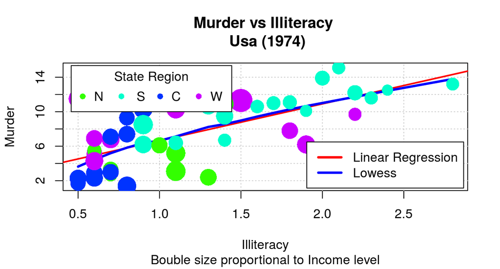

```r
title(main = "Murder vs Illiteracy \n Usa (1974)", cex = 1.2)
title(sub = "Bouble size proportional to Income level", cex = 1)
```

### Polygons

The `polygon()` function is used to draw a polygon in a plot. The basic arguments of the `polygon()` function are the `x` and `y` vectors which contain the coordinates of the vertices of the polygon. Therefore, the `x` and `y` arguments are numerical vectors with the same length. With this function the polygon is created by uniting the coordinates given in progression and is closed by joining the last point to the first.

```r
poly.x = c(sort(x), sort(x, dec = T))
poly.y = c(y1, sort(y2, dec = T))
```

In Code above x-values are defined from a vector with a length of $n/2$ in ascending order and linked to the vector itself in a descending order. In this way, the vector will be $n$-long, as the ordinate vector. This method will ensure the correct closure of the polygon.

The `polygon()` function can be useful to draw a confidence interval for the regression line.

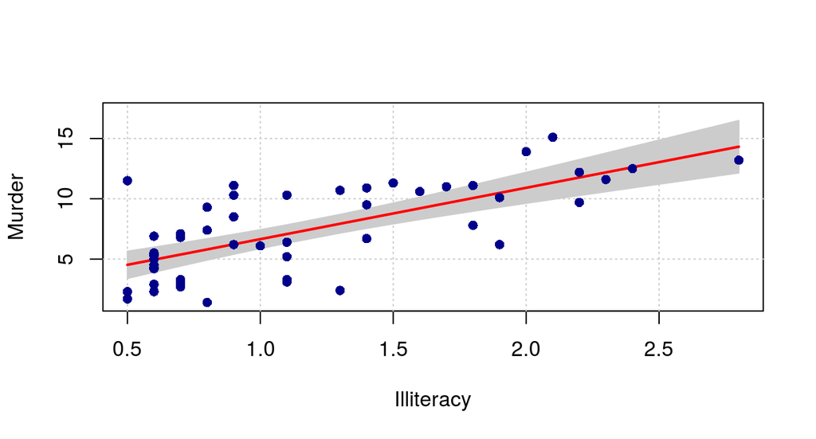

```r
fm = lm(Murder ~ Illiteracy, data = states)
newdata = data.frame(Illiteracy = sort(states$Illiteracy))
pred = as.data.frame(predict(object = fm, newdata = newdata,
  interval = "confidence"))
poly.x = c(sort(states$Illiteracy), sort(states$Illiteracy, dec = T))
poly.y = c(pred$upr, sort(pred$lwr, dec = T))
ylim = c(0.95, 1.05) * range(c(states$Murder, pred$lwr, pred$upr))
plot(Murder ~ Illiteracy, data = states, type = "n" ,ylim = ylim)
polygon(poly.x, poly.y, col = "gray80", border = "grey80")
grid(col = "gray80", lwd = 1, lty = 3)
lines(x = sort(states$Illiteracy), y = pred$fit, col = "red", lwd = 2)
points(Murder ~ Illiteracy, data = states, pch = 16, col = "darkblue")
```

A simple linear model has been estimated in Code above. The `predict()` function creates the matrix which contains the upper and lower limit of the confidence interval. In the `predict()` function the `newdata` parameter has been defined to order the values of confidence limits according to the values of the `Illiteracy` regressor.

Besides properly defined coordinates, the `polygon()` function also uses the `col` and `border` arguments to chose the area and border colours of the polygon. The limits of the y-axis have been redefined for them to be sufficiently wide to contain the whole confidence interval. Finally, the polygon has been created in the plot before drawing the points to prevent them from being hidden. The `lines()` function draws the regression line.

### Axes

The `axis()` function adds one or more axes to the plot. With the `axis()` function it is possible to specify location, density and labels. There are also numerous other functions. In particular, the `side` option determines the position of the axis: `1` = below, `2` = left, `3` = above and `4` = right. This parameter is obviously mandatory. An example of the application of the `axis()` function is provided in Code below. It is also shown how to create the grid in reference to the range defined by the new axes. Beside the `side` parameter, other fundamental arguments of the `axis()` function are `at` and `labels`. The `at` parameter defines the new location of the axes labels. The `labels` arguments indicates the character to be printed in each position. Clearly, the two vectors associated with the `at` and `labels` parameters need to have the same length.

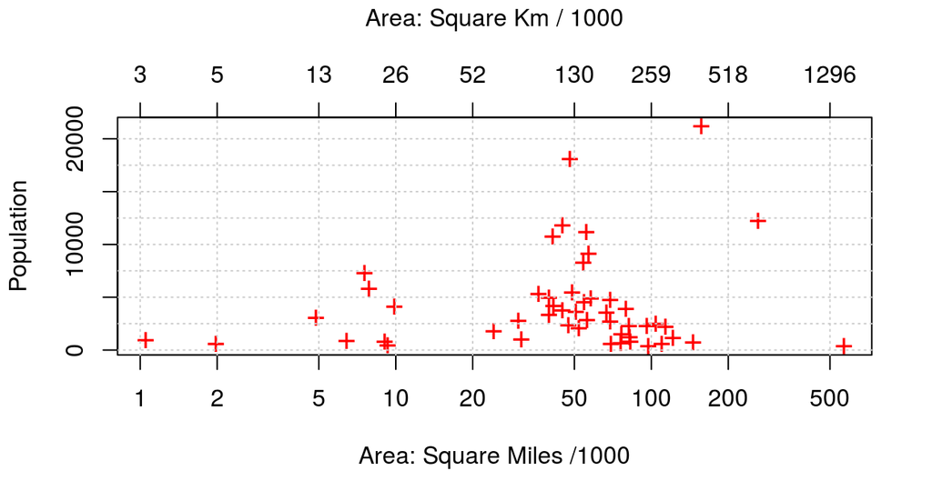

```r
plot(Population ~ Area, data = states, log = "x", pch = "+", cex = 1.5,
  xaxt = "n", xlab = "Area: Square Miles /1000", col = "red")
atx.mg = c(1, 2, 5, 10, 20, 50, 100, 200, 500) * 1000
label.mg = c(1, 2, 5, 10, 20, 50, 100, 200, 500)
label.km = round(label.mg * 1.61^2, 0)
aty = seq(0, 20, by = 2.5) * 1000
axis(1, at = atx.mg, labels = label.mg)
axis(3, at = atx.mg, labels = label.km)
abline(h = aty, v = atx.mg, col = "gray80", lty = 3)
mtext("Area: Square Km / 1000", 3, line = 3)
```

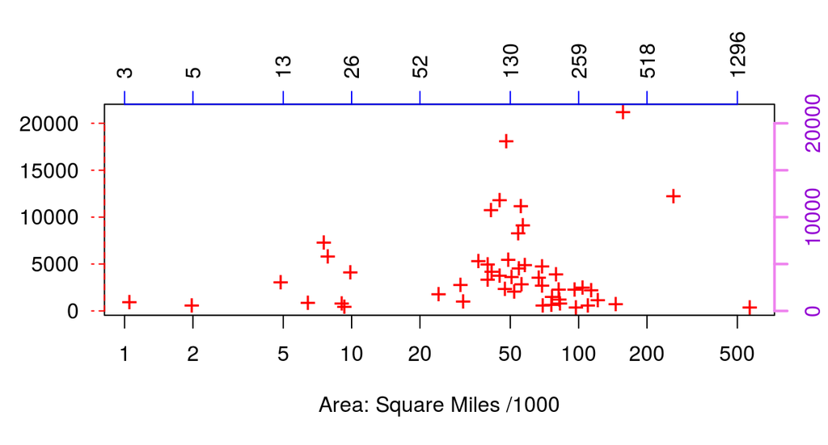

```r
plot(Population ~ Area, data = states, log = "x", pch = "+",
  cex = 1.5,xaxt = "n", yaxt = "n",
  xlab = "Area: Square Miles /1000", ylab = "", col = "red")
axis(1, at = atx.mg, labels = label.mg)
axis(2, col = "red", lty = 2, las = 2)
axis(3, at = atx.mg, labels = label.km, las = 2, col ="blue")
axis(4, col = "violet", col.axis = "dark violet", lwd = 2)
```

## Histograms, Barplot, Boxplot and Three Dimensional Plots

### Histograms

A histogram is a representation of a frequency distribution by means of rectangles whose widths represent class intervals and whose areas are proportional to the corresponding frequencies.

When the `freq` argument of `hist()` is set to `FALSE` probability densities are plotted so that the histogram has a total area of one.

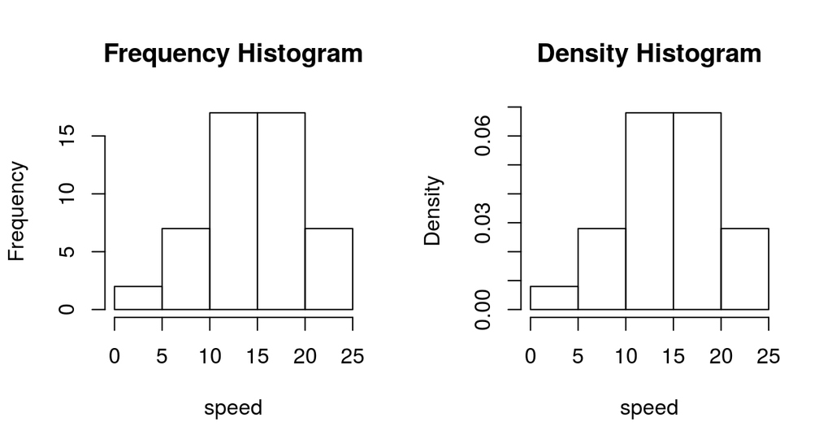

```r
op = par(mfrow = c(1, 2))
with (cars, {
  hist(speed, main = "Frequency Histogram")
  hist(speed, freq = F, main = "Density Histogram")
})
```

The number of breaks/classes is automatically determined but can be defined if required by specifying either the numbers of classes or the break points:

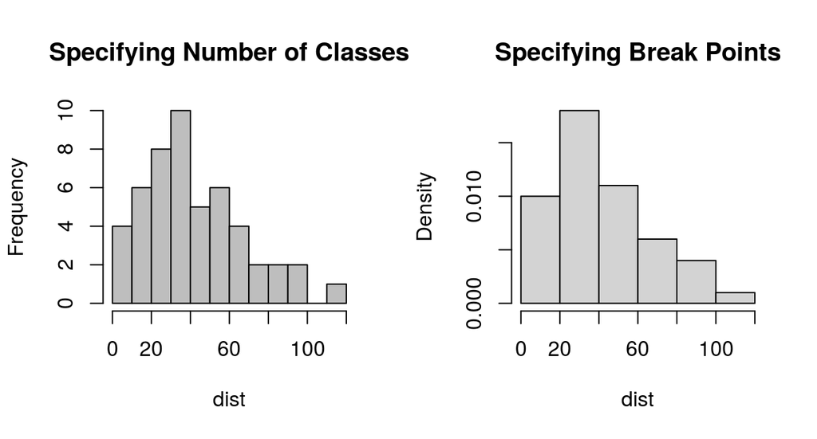

```r
par(mfrow = c(1, 2))
with (cars, {
  hist(dist, nclass = 12,
    main = "Specifying Number of Classes", col = "gray")
  hist(dist, nclass = seq(0, 120, by = 20), freq = F,
    main = "Specifying Break Points", col = "lightgray")
})
```

### Barplot

A bar plot displays the frequencies (or relative frequencies) for categorical variables. Generally, a grouping function such as `table()` is applied to data prior to draw barplots.

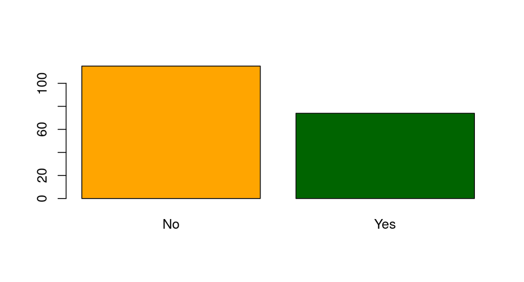

```r
load("bwt.Rda")
with (bwt , {
  tb = table (smoke)
  barplot(tb, col = c("orange", "darkgreen"))
})
```

When introducing two or more variables, barplots can be constructed in stacked or beside mode. A simple legend may added to the plot by setting to `TRUE` the `legend` argument.

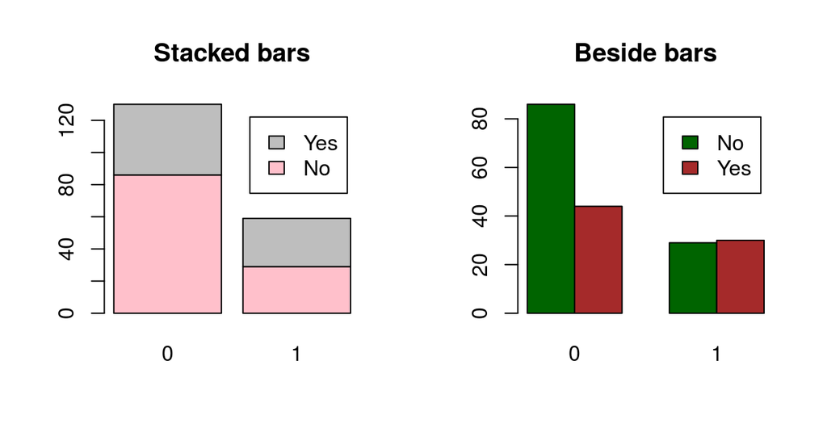

```r
with (bwt , {
  tb = table (smoke, low)
  par(mfrow = c(1,2))
  barplot(tb, col = c("pink", "gray"), main = "Stacked bars",
    legend = T)
  barplot(tb, col = c("darkgreen", "brown"), main = "Beside bars",
    beside = T, legend = T)
})
```

### Boxplot

“Box and whiskers” plots, often called boxplots, are a way of summarizing and comparing data distributions.

The “box” in a boxplot shows the median as a line and the first (25th percentile) and third quartile (75th percentile) of the distribution as the lower and upper parts of the box.

The “whiskers” shown above and below the boxes technically represent the largest and smallest observed data that are less than 1.5 box lengths from the end of the box. In practice, these data are about the lowest and highest values one is likely to observe. Data above or below whiskers are shown as open circles “o” or stars.

In comparing the boxplots across groups, a simple summary is to say that the “box” area for one group is higher or lower than that for another group.

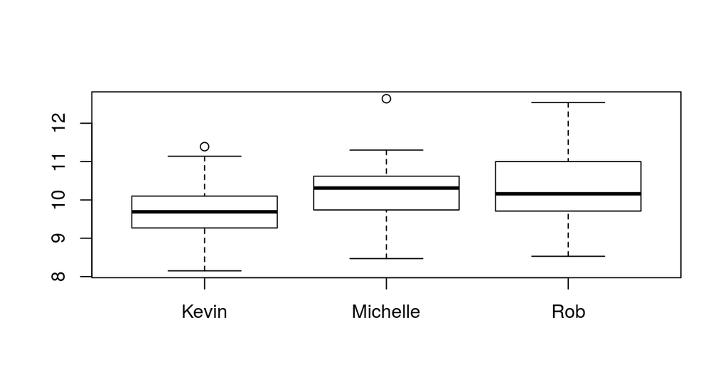

```r
load("carseat.Rda")
boxplot(Strength ~ Operator, data = carseat)
```

Formula method seems to be the only alternative unless reshaping data in wide format before drawing the boxplot.